# hw3

cyber-atlas

February 13, 2019

1. Returns the number of parties the waiter served

```r
data(tips, package="reshape2")
head(tips)
```

```
##   total_bill  tip    sex smoker day   time size
## 1      16.99 1.01 Female     No Sun Dinner    2
## 2      10.34 1.66   Male     No Sun Dinner    3
## 3      21.01 3.50   Male     No Sun Dinner    3
## 4      23.68 3.31   Male     No Sun Dinner    2
## 5      24.59 3.61 Female     No Sun Dinner    4
## 6      25.29 4.71   Male     No Sun Dinner    4
```

```r
#Returns the number
numParty <- nrow(tips)
#The number of parties
numParty
```

```
## [1] 244
```

```r
#Goes throught the indeces of the columns of the dataframe and returns the typeof them
sapply(tips, typeof)
```

```
## total_bill        tip        sex     smoker        day       time
##   "double"   "double"  "integer"  "integer"  "integer"  "integer"
##       size
##  "integer"
```

```r
#data(tips, package="reshape2")
day <- tips$day

class(tips$day)
```

```
## [1] "factor"
```

```r
day <- day[order(match(day,  c("Thur","Fri","Sat","Sun")))]
#head(day)
day
```

```
##   [1] Thur Thur Thur Thur Thur Thur Thur Thur Thur Thur Thur Thur Thur Thur
##  [15] Thur Thur Thur Thur Thur Thur Thur Thur Thur Thur Thur Thur Thur Thur
##  [29] Thur Thur Thur Thur Thur Thur Thur Thur Thur Thur Thur Thur Thur Thur
##  [43] Thur Thur Thur Thur Thur Thur Thur Thur Thur Thur Thur Thur Thur Thur
##  [57] Thur Thur Thur Thur Thur Thur Fri  Fri  Fri  Fri  Fri  Fri  Fri  Fri
##  [71] Fri  Fri  Fri  Fri  Fri  Fri  Fri  Fri  Fri  Fri  Fri  Sat  Sat  Sat
##  [85] Sat  Sat  Sat  Sat  Sat  Sat  Sat  Sat  Sat  Sat  Sat  Sat  Sat  Sat
##  [99] Sat  Sat  Sat  Sat  Sat  Sat  Sat  Sat  Sat  Sat  Sat  Sat  Sat  Sat
## [113] Sat  Sat  Sat  Sat  Sat  Sat  Sat  Sat  Sat  Sat  Sat  Sat  Sat  Sat
## [127] Sat  Sat  Sat  Sat  Sat  Sat  Sat  Sat  Sat  Sat  Sat  Sat  Sat  Sat
## [141] Sat  Sat  Sat  Sat  Sat  Sat  Sat  Sat  Sat  Sat  Sat  Sat  Sat  Sat
## [155] Sat  Sat  Sat  Sat  Sat  Sat  Sat  Sat  Sat  Sat  Sat  Sat  Sat  Sat
## [169] Sun  Sun  Sun  Sun  Sun  Sun  Sun  Sun  Sun  Sun  Sun  Sun  Sun  Sun
## [183] Sun  Sun  Sun  Sun  Sun  Sun  Sun  Sun  Sun  Sun  Sun  Sun  Sun  Sun
## [197] Sun  Sun  Sun  Sun  Sun  Sun  Sun  Sun  Sun  Sun  Sun  Sun  Sun  Sun
## [211] Sun  Sun  Sun  Sun  Sun  Sun  Sun  Sun  Sun  Sun  Sun  Sun  Sun  Sun
## [225] Sun  Sun  Sun  Sun  Sun  Sun  Sun  Sun  Sun  Sun  Sun  Sun  Sun  Sun
## [239] Sun  Sun  Sun  Sun  Sun  Sun
## Levels: Fri Sat Sun Thur
```

```r
#Make a dataframe of the meals with a party greater than or equal to 5 people that was paid by a female
female5 <- tips[tips$sex == 'Female' & tips$size >= 5,]
#Prove that it's a dataframe
class(female5)
```

```
## [1] "data.frame"
```

```r
#Print the female5 dataframe
female5
```

```
##     total_bill  tip    sex smoker  day   time size
## 126      29.80 4.20 Female     No Thur  Lunch    6
## 144      27.05 5.00 Female     No Thur  Lunch    6
## 156      29.85 5.14 Female     No  Sun Dinner    5
```

```r
library(ggplot2)
head(tips)
```

```
##   total_bill  tip    sex smoker day   time size
## 1      16.99 1.01 Female     No Sun Dinner    2
## 2      10.34 1.66   Male     No Sun Dinner    3
## 3      21.01 3.50   Male     No Sun Dinner    3
## 4      23.68 3.31   Male     No Sun Dinner    2
## 5      24.59 3.61 Female     No Sun Dinner    4
## 6      25.29 4.71   Male     No Sun Dinner    4
```

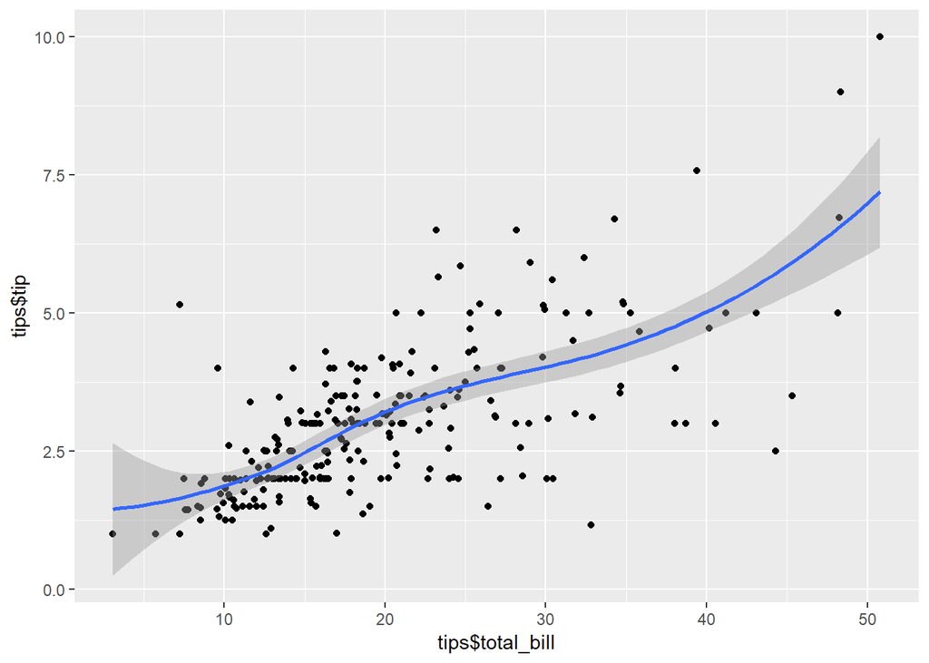

```r
#Scatter plot showing the tips based on the total bill
ggplot(tips, aes(x= tips$total_bill, y=tips$tip))+
  geom_point()+
  geom_smooth()
```

One anomoly in the dataset is that a majority of the points are clustered in the under $25 range and less points are above that. So there is not an even amount of data for both ranges. Another anomoly is that on both low end and the high end, there are outliers. Above the $30 mark the tips as a whole did not increase by much, except for some very high tips (outliers) which skew the trend line.

```r
tiprate <- tips
class(tiprate)
```

```
## [1] "data.frame"
```

```r
tips$tiprate <- tiprate$tip/tiprate$total_bill
mean(tips$tiprate)
```

```
## [1] 0.1608026
```

The average tiprate is 16%

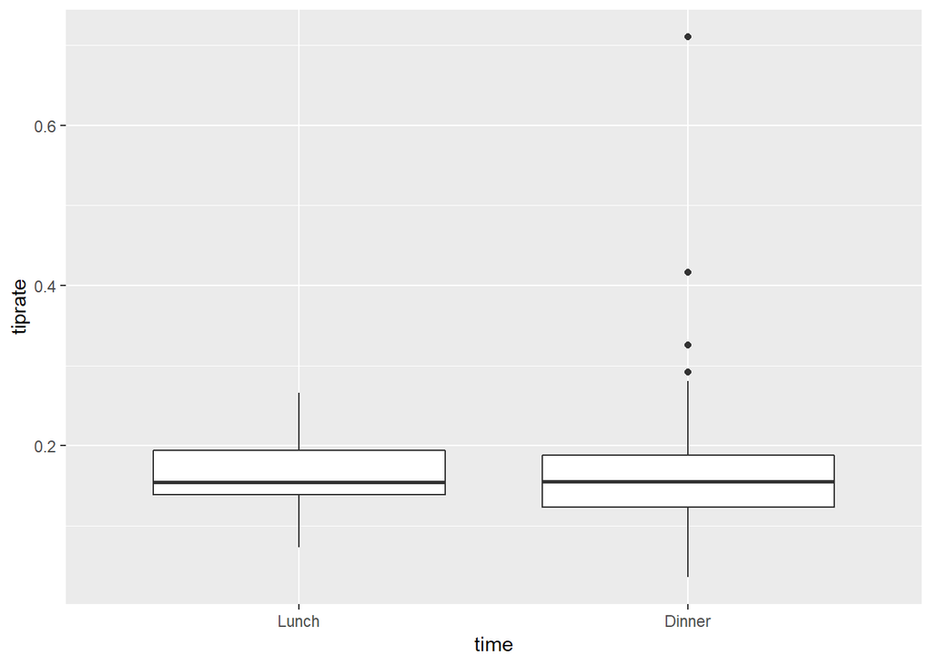

```r
ggplot(tips, aes(x=time, y=tiprate))+
  geom_boxplot()+
  #Allows, to specify labels, in which order, we want on the scale
  scale_x_discrete(limits=c("Lunch", "Dinner"))
```

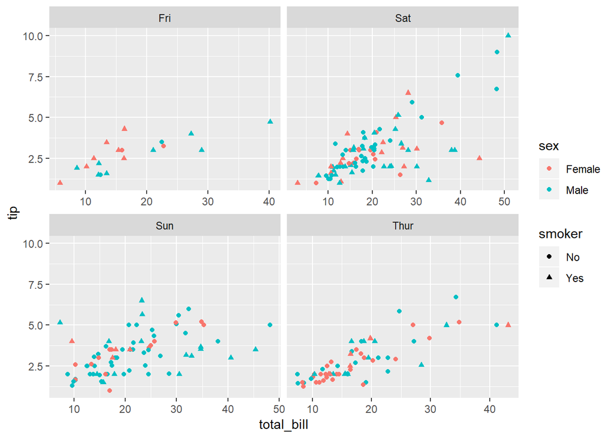

```r
#relationship between tip, total bill, female smoker, male smoker, female non smoker, male non smoker

ggplot(tips, aes(x=total_bill, y=tip,  color=sex, shape=smoker))+ geom_point()+ facet_wrap(~day, scales='free_x')
```

When the bill is lower the outliers that tip higher are smokers, independent of sex. Wehn the bill is higher, the amount of the tip is about equal regarless if they smoke. Mostly men are paying the more expensive bills.

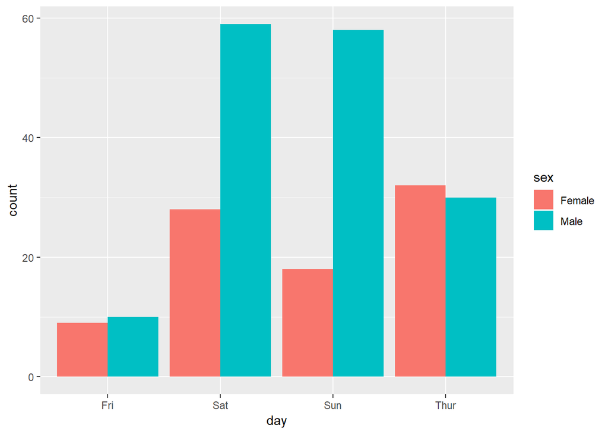

```r
ggplot(tips, aes(x=day, fill=sex)) + geom_bar(position="dodge")
```

Based on the relationship shown in the gaph, we can conclude that on average men pay for a majority of the bills on Saturdays and Sundays. On Thursday Women pay more than men, and on Fridays it’s roughly equal with men paying slighly more.